# Stat 8054 Doing Assignment 4

## 4.1 Specific question 1

This one is pretty easy, we just need to convert $\boldsymbol \beta$ to $\boldsymbol \theta$ for this specific game,

```r
mydata[267, ]
```

```
##     home.team road.team neutral regular homewin roadwin tie
## 267        12         3       1       0       1       0   0
```

```r
n <- 267 # game index
outfun <- function(beta) {
    theta_i <- M[, , n] %*% beta
    # deal with non-regular session
    if (mydata[n, "regular"] == 0)
        theta_i[3, 1] <- -Inf # always -Inf so 0 prob for tie in post-session

    exp(theta_i) / sum(exp(theta_i))
}
```

Similarly, we have saved the result and just to load it to the workspace to save the compiling time.

```r
mout_1 <- metrop(mout, blen = 1000, outfun = outfun)
save(mout_1, file = "mout_Q1.RData")
```

```r
load(file = "mout_Q1.RData")
prob <- colMeans(mout_1$batch)
names(prob) <- c("homewin", "roadwin", "tie")
prob
```

```
##   homewin   roadwin       tie
## 0.4631087 0.5368913 0.0000000
```

```r
nfl2019[267, 1:4]
```

```
##     road.team home.team road.score home.score
## 267     49ers    Chiefs         20         31
```

The simulation shows that if we replayed the game, 49ers is more likely (0.5369) to win as a road team.

To check the chain with some plots, they look good.

```r
foo <- as.ts(mout_1$batch[, 1:2])
```

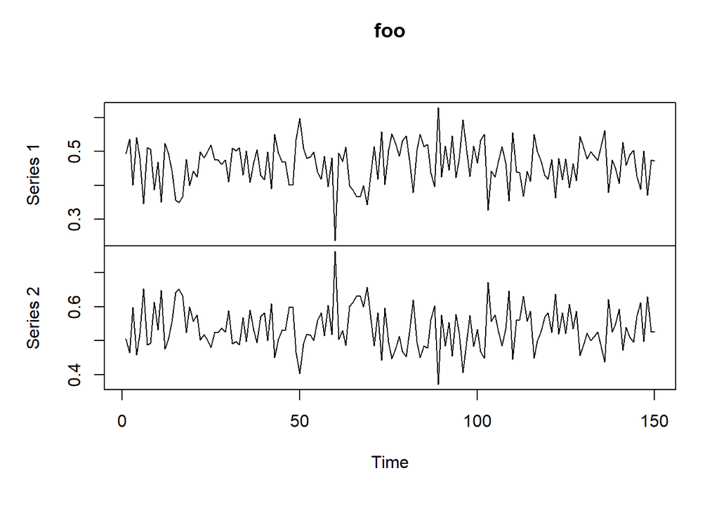

```r
plot(foo)
```

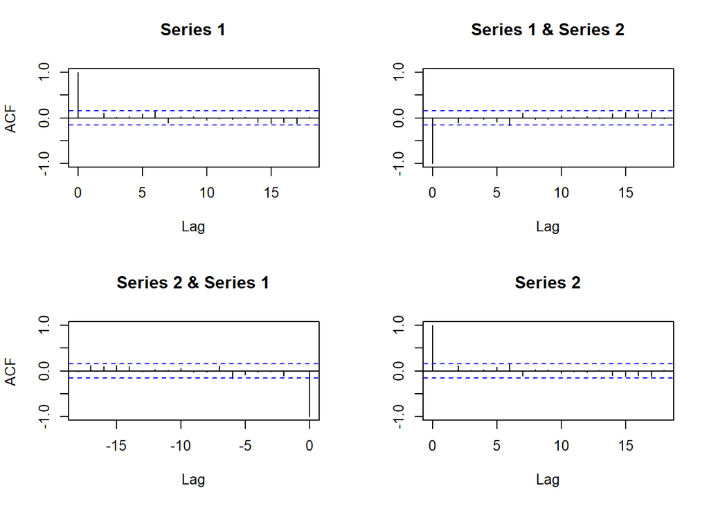

```r
acf(foo)
```

## 4.2 Specific question 2

This one is quite compliated, but one can simulate the final winner according to the described rules. We first prepare a dataset that contains all necessary information (`teamname`, `teamindex`, `seed`, `conf`) for all teams invovled in playoffs.

```r
# related teams and their index
finalteams <- with(nfl2019[257:267, ], unique(union(home.team, road.team))) # 12
teamindex <- which(varname %in% finalteams)
teamname <- varname[teamindex]

teamseed <- rep(0, 12)
teamconf <- rep("AFC", 12)
temp <- nfl2019[257:266, ] # no need for the last game with two diff confs
for (i in 1:dim(temp)[1]) {
    index <- which(teamname == temp$road.team[i])
    teamseed[index] <- temp$road.seed[i]
    teamconf[index] <- temp$conf[i]

    index <- which(teamname == temp$home.team[i])
    teamseed[index] <- temp$home.seed[i]
    teamconf[index] <- temp$conf[i]
}
# aggregate information of teams in the playoffs
finalgames <- data.frame(teamname, teamindex, teamseed, teamconf)
head(finalgames)
```

```
##   teamname teamindex teamseed teamconf
## 1    49ers         3        1      NFC
## 2    Bills         6        5      AFC
## 3   Chiefs        12        2      AFC
## 4   Eagles        16        4      NFC
## 5  Packers        22        2      NFC
## 6 Patriots        24        3      AFC
```

Then we need an output function that can take $\boldsymbol \beta$ as input, and output a final winner based on the complicated matching rule. The function below `outfun2` could have been designed cleverly, but I just implement it with ``brute force’’. That should be okay as long as I can have the right mapping relationship.

```r
outfun2 <- function(beta) {
    # within AFC
    ## result of week 18
    w18_AFC1 <- ifelse(beta[2] + beta[32] > beta[6], 32, 6)
    w18_AFC2 <- ifelse(beta[2] + beta[24] > beta[33], 24, 33)
    ### record seed information
    seed1 <- with(finalgames, teamseed[teamindex == w18_AFC1])
    seed2 <- with(finalgames, teamseed[teamindex == w18_AFC2])
    ## result of week 19
    if (seed1 < seed2) {
        w19_AFC1 <- ifelse(beta[2] + beta[27] > beta[w18_AFC1], 27, w18_AFC1)
        w19_AFC2 <- ifelse(beta[2] + beta[12] > beta[w18_AFC2], 12, w18_AFC2)
    }
    if (seed1 > seed2) {
        w19_AFC1 <- ifelse(beta[2] + beta[27] > beta[w18_AFC2], 27, w18_AFC2)
        w19_AFC2 <- ifelse(beta[2] + beta[12] > beta[w18_AFC1], 12, w18_AFC1)
    }
    ### record seed information
    seed1 <- with(finalgames, teamseed[teamindex == w19_AFC1])
    seed2 <- with(finalgames, teamseed[teamindex == w19_AFC2])
    ## result of week 20
    if (seed1 < seed2)
        w20_AFC <- ifelse(beta[2] + beta[w19_AFC1] > beta[w19_AFC2],
                          w19_AFC1, w19_AFC2)
    if (seed1 > seed2)
        w20_AFC <- ifelse(beta[2] + beta[w19_AFC2] > beta[w19_AFC1],
                          w19_AFC2, w19_AFC1)

    # within NFC
    ## result of week 18
    w18_NFC1 <- ifelse(beta[2] + beta[29] > beta[34], 29, 34)
    w18_NFC2 <- ifelse(beta[2] + beta[16] > beta[30], 16, 30)
    ### record seed information
    seed1 <- with(finalgames, teamseed[teamindex == w18_NFC1])
    seed2 <- with(finalgames, teamseed[teamindex == w18_NFC2])
    ## result of week 19
    if (seed1 < seed2) {
        w19_NFC1 <- ifelse(beta[2] + beta[3] > beta[w18_NFC1], 3, w18_NFC1)
        w19_NFC2 <- ifelse(beta[2] + beta[22] > beta[w18_NFC2], 22, w18_NFC2)
    }
    if (seed1 > seed2) {
        w19_NFC1 <- ifelse(beta[2] + beta[3] > beta[w18_NFC2], 3, w18_NFC2)
        w19_NFC2 <- ifelse(beta[2] + beta[22] > beta[w18_NFC1], 22, w18_NFC1)
    }
    ### record seed information
    seed1 <- with(finalgames, teamseed[teamindex == w19_NFC1])
    seed2 <- with(finalgames, teamseed[teamindex == w19_NFC2])
    ## result of week 20
    if (seed1 < seed2)
        w20_NFC <- ifelse(beta[2] + beta[w19_NFC1] > beta[w19_NFC2],
                          w19_NFC1, w19_NFC2)
    if (seed1 > seed2)
        w20_NFC <- ifelse(beta[2] + beta[w19_NFC2] > beta[w19_NFC1],
                          w19_NFC2, w19_NFC1)

    # final game between AFC and NFC! week 21!
    w21 <- ifelse(beta[w20_AFC] > beta[w20_NFC], w20_AFC, w20_NFC)

    result <- rep(0, dim(finalgames)[1])
    index <- with(finalgames, which(teamindex == w21))
    result[index] <- 1
    names(result) <- finalgames$teamname
    result
}
```

As usual, I ran a chain with `outfun2`, save it, and load it when needed to save compiling time.

```r
mout_2 <- metrop(mout, blen = 1000, outfun = outfun2)
save(mout_2, file = "mout_Q2.RData")
```

```r
load(file = "mout_Q2.RData")
winprob <- colMeans(mout_2$batch)
names(winprob) <- finalgames$teamname
winprob
```

```
##        49ers        Bills       Chiefs       Eagles      Packers
## 0.2996066667 0.0002933333 0.1732600000 0.0003466667 0.1257066667
##     Patriots       Ravens       Saints     Seahawks       Texans
## 0.0116266667 0.2669133333 0.0932066667 0.0181866667 0.0044933333
##       Titans      Vikings
## 0.0014933333 0.0048666667
```

As we can see, according to the simulation, 49ers is mostly likely to be the champion, followed by Ravens, Chiefs and Packers. We can take the significant result (say, $>0.1$), and get MCSE,

```r
# take results that are significant
foo <- as.ts(mout_2$batch)
colnames(foo) <- finalgames$teamname
foo <- foo[, colMeans(foo) > 0.1]
mcse <- apply(foo, 2, sd) / sqrt(mout$nbatch)
rbind(batchest = colMeans(foo), mcse)
```

```
##               49ers      Chiefs     Packers     Ravens
## batchest 0.29960667 0.173260000 0.125706667 0.26691333
## mcse     0.01059398 0.008682098 0.008321577 0.01102951
```

and we can check these chains with plots,

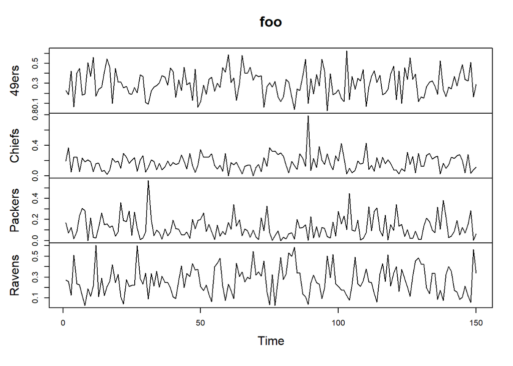

```r
plot(foo)
```

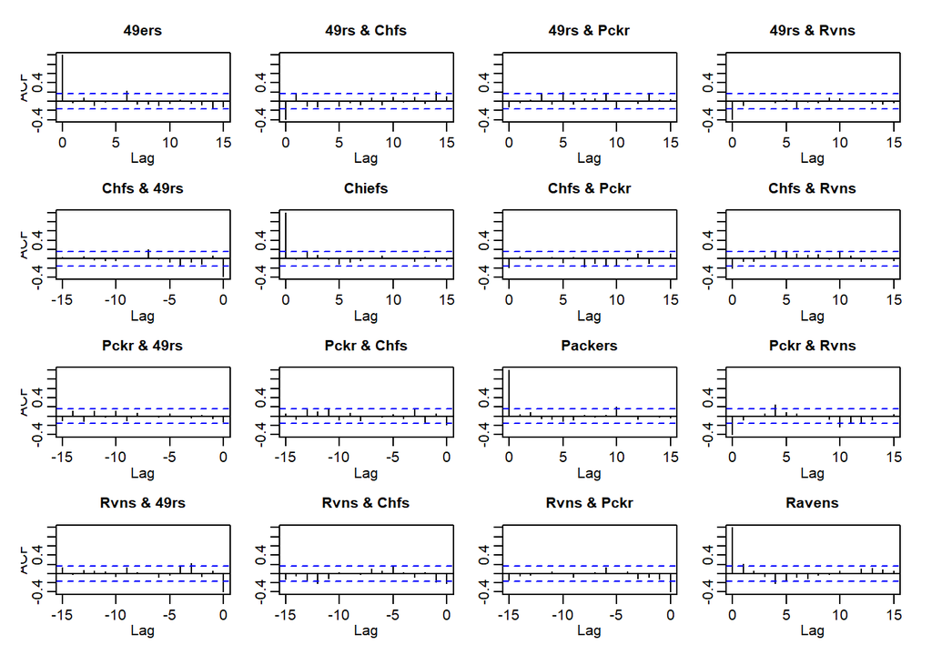

```r
acf(foo)
```